# Final Project BDACM

Regina Gerber

Due: Thursday, February 28th

# Final Project Bayesian Data Analysis and Cognitive Modelling - Part 1: Visualization

The dataset here is a sample of the transactions made in a retail store. The store wants to know better the customer purchase behaviour against different products. Specifically, here the problem is a regression problem where we are trying to predict the dependent variable (the amount of purchase) with the help of the information contained in the other variables.

## 0. Loading required packages

```r
# Required R packages
library(tidyverse)
library(BSDA)
```

```r
library(cowplot)
library(GGally)
library(scales)
library(ggpubr)
library(brms)
# set cores to use to the total number of cores (minimally 4)
options(mc.cores = max(parallel::detectCores(), 4))

lastname <- "gerber"
```

## 1. Inspecting the Data

#### 1a) Loading the data

Description: The Data contains 12 different variables and 537.577 rows: “User_ID” (nominal), “Product_ID”(nominal), “Gender”(binary/nominal), “Age”(7-level ordinal), “Occupation”(nominal/ordinal?), “City_Category”(nominal), “Stay_In_Current_City”(count), “Marital_Status”(binary), “Product_Category_1”(nominal), “Product_Category_2”(nominal),“Product_Category_3”(nominal), “Purchase”(metric). Some varibles cannot be interpreted directly as they are masked (“Product_ID”, “Occupation”, “City_Category”, “Marital_Status”).

The first variables are defined as the predictor (or independent) variables, the last is the predicted (or dependent) variable. In other words: We want to predict “Purchase” by the combination of the other variables.

```r
bf_data<-read.csv(file="C:/Users/regina/Desktop/DSproject/original_bf_data.csv", header = TRUE, sep = ",")

#Print the Column Names and the 10 first data points
head(bf_data, n=10)
```

```
##    User_ID Product_ID Gender   Age Occupation City_Category
## 1  1000001  P00069042      F  0-17         10             A
## 2  1000001  P00248942      F  0-17         10             A
## 3  1000001  P00087842      F  0-17         10             A
## 4  1000001  P00085442      F  0-17         10             A
## 5  1000002  P00285442      M   55+         16             C
## 6  1000003  P00193542      M 26-35         15             A
## 7  1000004  P00184942      M 46-50          7             B
## 8  1000004  P00346142      M 46-50          7             B
## 9  1000004   P0097242      M 46-50          7             B
## 10 1000005  P00274942      M 26-35         20             A
##    Stay_In_Current_City_Years Marital_Status Product_Category_1
## 1                           2              0                  3
## 2                           2              0                  1
## 3                           2              0                 12
```

[output cut: 18 more lines]

```r
#Print a statistical summary of all factors
summary(bf_data)
```

```
##     User_ID            Product_ID     Gender        Age
##  Min.   :1000001   P00265242:  1858   F:132197   0-17 : 14707
##  1st Qu.:1001495   P00110742:  1591   M:405380   18-25: 97634
##  Median :1003031   P00025442:  1586              26-35:214690
##  Mean   :1002992   P00112142:  1539              36-45:107499
##  3rd Qu.:1004417   P00057642:  1430              46-50: 44526
##  Max.   :1006040   P00184942:  1424              51-55: 37618
##                    (Other)  :528149              55+  : 20903
##    Occupation     City_Category Stay_In_Current_City_Years
##  Min.   : 0.000   A:144638      0 : 72725
##  1st Qu.: 2.000   B:226493      1 :189192
##  Median : 7.000   C:166446      2 : 99459
##  Mean   : 8.083                 3 : 93312
##  3rd Qu.:14.000                 4+: 82889
##  Max.   :20.000
##
##  Marital_Status   Product_Category_1 Product_Category_2 Product_Category_3
##  Min.   :0.0000   Min.   : 1.000     Min.   : 2.00      Min.   : 3.0
##  1st Qu.:0.0000   1st Qu.: 1.000     1st Qu.: 5.00      1st Qu.: 9.0
##  Median :0.0000   Median : 5.000     Median : 9.00      Median :14.0
##  Mean   :0.4088   Mean   : 5.296     Mean   : 9.84      Mean   :12.7
##  3rd Qu.:1.0000   3rd Qu.: 8.000     3rd Qu.:15.00      3rd Qu.:16.0
##  Max.   :1.0000   Max.   :18.000     Max.   :18.00      Max.   :18.0
##                                      NA's   :166986     NA's   :373299
##     Purchase
##  Min.   :  185
##  1st Qu.: 5866
##  Median : 8062
##  Mean   : 9334
##  3rd Qu.:12073
##  Max.   :23961
##
```

#### 1b) Exploring the data

For our purposes we will drop(*) the variables “City_Category”, “Stay_in_current_Years”, “Occupation”, “Product_Category_1”, “Product_Category_2”, and “Product_Category_3” to reduce the complexity in following ways: 1) reduce the amount of possible predictor variables, 2) reduce the types of possible predictor variables by discarding “Stay_in_current_Years” as a count-variable, 3) to outscope possible misinterpretations of the variable types “Occupation” (ordinal vs. nominal) and their meaning (partly hidden by masking).

Thus, our resulting predictor variables contain following types: * *binary/binomial* + *Gender*, + *Marital Status*, * *nominal* + *User_ID*, + *Product_ID*, * *ordinal* + *Age*

predicting a metric (dependent) variable: Purchase.

Within the rows the varaible “User_ID” shows, that some customers are listet several times. This should be kept in mind for further analysis. Additionally, we should check for missing values.

(*)side-note: Instead of an uninformed dropping of information, it is more sensible to discard single factors that yields less to the explanation of the data. One commonly used method to find those factors is to conduct a Principle Component Analysis, which is a mathematical procedure of dimension reduction that transforms a number of possible correlated variables into a smaller number of uncorrelated variables (called principle component)(Guo, Wu, Massart, Boucon & de Jong, 2002). Yet, since our data is strongly heterogeneous, that is, it contains continuous and categorical variables, we are not allowed to use Principle Component Analysis (PCA)(used for continuous data only) or Multiple Correspondence Analysis (MCA) (used for nominal categorical data only) to detect an underlying structure in our data set. Instead, we can use Factor Analysis for Mixed Data, which is a principle component method to explore data with both continous and categorical variables (for further information see FAMD {FactorMineR}). However, this procedure is theoretically quite complex and additionally costly in term of processing power, therefore, I skipped it out and arbitrarily dropped some factors that may be less infomrative.

#### 1c) Preparing the data

We will remove some columns and check the levels of the different factors

```r
#Remove columns/variables we are not interested in

new_bf_data <- bf_data %>%  subset(select = -c(Stay_In_Current_City_Years,City_Category,Occupation, Product_Category_1,Product_Category_2, Product_Category_3 )) %>%  mutate(Marital_Status = factor(Marital_Status))

head(new_bf_data)
```

```
##   User_ID Product_ID Gender   Age Marital_Status Purchase
## 1 1000001  P00069042      F  0-17              0     8370
## 2 1000001  P00248942      F  0-17              0    15200
## 3 1000001  P00087842      F  0-17              0     1422
## 4 1000001  P00085442      F  0-17              0     1057
## 5 1000002  P00285442      M   55+              0     7969
## 6 1000003  P00193542      M 26-35              0    15227
```

```r
write.csv(new_bf_data,file="C:/Users/regina/Desktop/DSproject/new_bf_data.csv")

# Check the different levels of the variables/factors:

# How many actual customers are there?
all_User_IDs<- unique(bf_data$User_ID)
n_user_id<-bf_data %>% group_by(User_ID) %>% summarize(count=n())
paste0("There are ",
      count(n_user_id),
      " different Customers.")
```

```
## [1] "There are 5891 different Customers."
```

```r
# How many differenct Product_IDs are there?
all_Product_IDs<- unique(bf_data$Product_ID)
m_product_id<-bf_data %>% group_by(Product_ID) %>% summarize(count=n())
paste0("There are ",
      count(m_product_id),
      " different Products")
```

```
## [1] "There are 3623 different Products"
```

```r
# How many different age classes are there?
age_classes<-bf_data %>% group_by(Age) %>% summarize(count=n())
paste0("There are ",
      count(age_classes),
      " different Age classes.Following Age classes are defined: ")
```

```
## [1] "There are 7 different Age classes.Following Age classes are defined: "
```

```r
print(age_classes$Age)
```

```
## [1] 0-17  18-25 26-35 36-45 46-50 51-55 55+
## Levels: 0-17 18-25 26-35 36-45 46-50 51-55 55+
```

```r
# Are there missing values? Where and how often?
for (Var in names(bf_data)) {
    missing <- sum(is.na(bf_data[,Var]))
    if (missing > 0) {
        print(c(Var,missing))
    }
}
```

```
## [1] "Product_Category_2" "166986"
## [1] "Product_Category_3" "373299"
```

## 2. Visualizing the data (under the Research Question)

“Is there a Difference in Purchase between males and females?”"

Let’s first have some differend visualizations of the variables.

#### 2a) Plotting histograms and density plots.

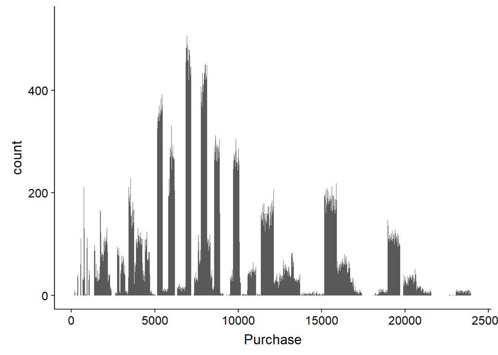

```r
#Histogram Purchase
bf_data %>% ggplot(mapping=aes(x=Purchase), xlab="Purchase", ylab="Count")+
  geom_histogram(binwidth = 3)
```

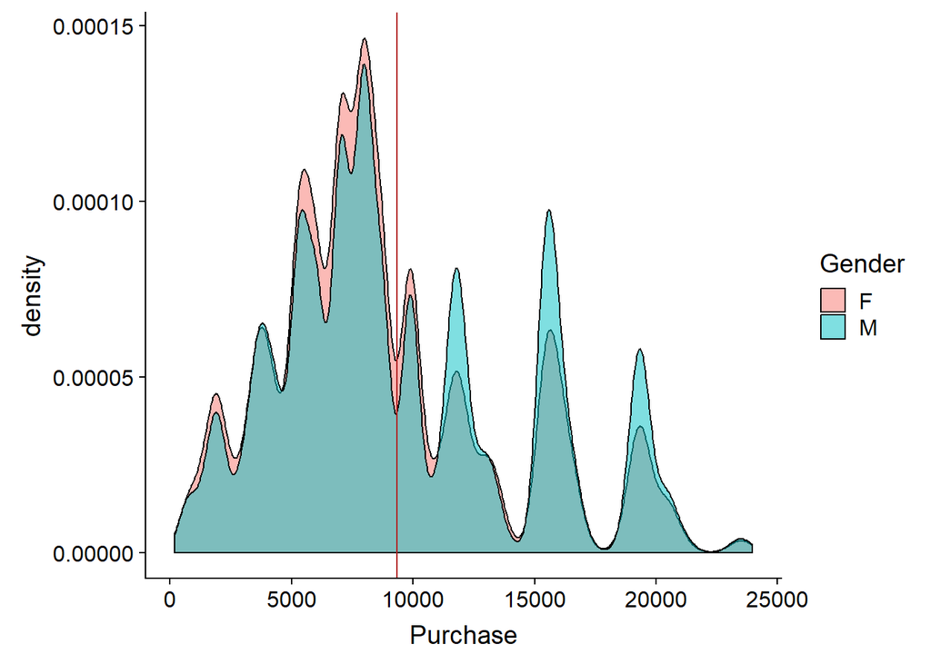

```r
#density plot of the Purchase  with respect to the groups "female" and "male", including group average
group_avg <- mean(bf_data$Purchase)
bf_data %>%
  ggplot(mapping = aes(x = Purchase, fill = Gender)) +
  geom_density(alpha = 0.5) +
  geom_vline(xintercept = group_avg, color = "firebrick")
```

```r
  theme_classic()
```

[output not shown]

[output cut: 334 more lines]

[output not shown]

Interpretation: The density plot shows that the data is rather “spread” across different intervals. Since we have to guarantee that the samples are drawn from a normal distribution (in order to account for a frequentist approach), we have to check the prerequisite. This can be done visually with an additional qqplot (or quantile-quantile plot).

#### 2b) Plotting a QQ-Plot

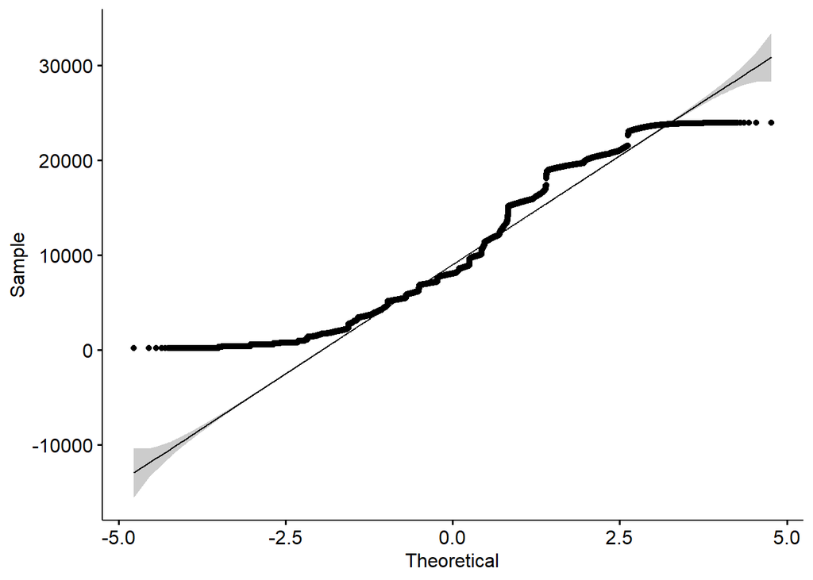

```r
#qq-plot of purchase for visually inspecting the data for the normality assumption
# (that residuals are normally distributed)

ggqqplot(bf_data$Purchase)
```

#### 2c) More paired plots

Furthermore, it can be useful to visually inspect the relations between Age, Purchase and Gender by plotting all variables against each other.

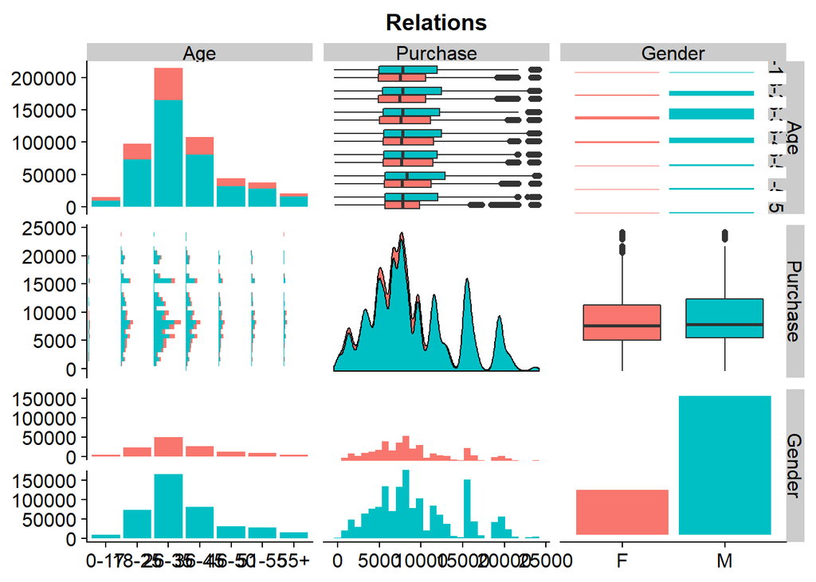

```r
p1<- bf_data %>%
  ggpairs(mapping = aes(color = Gender), title= "Relations",columns = c("Age", "Purchase", "Gender"))
p1
```

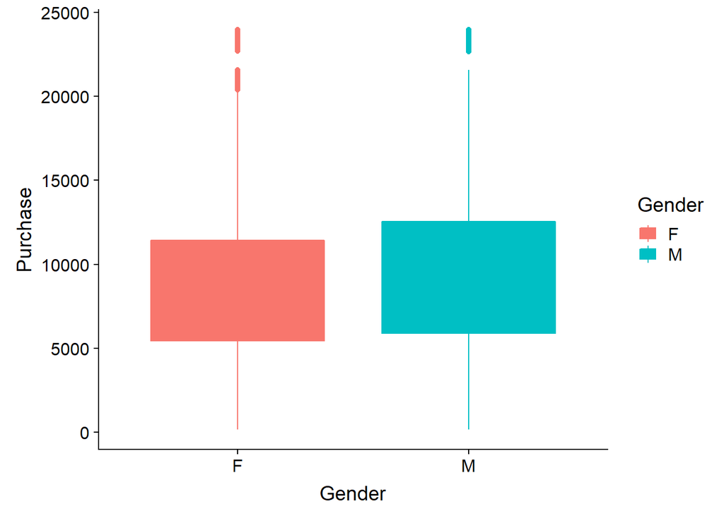

```r
#retrieve the second row, third column plot (Boxplot Purchase x Gender)
p <- p1[2,3]
p <- p + aes(color = Gender)

p
```

Interpretation: The boxplot seems more interesting regarding our first research question: “Is there a Difference in Purchase between males and females?”. The boxplot shows, that there are some outliers in both groups. The ranges and the means between the groups do not appear to be far away from each other. Let’s check.

```r
#Calculate mean, sd, min, max for the two groups
bf_gender_purchase <- bf_data %>% group_by(Gender) %>%
  summarise(mean_purchase= mean(Purchase), sd_purchase = sd(Purchase), min_purchase = min(Purchase),
            max_purchase = max(Purchase))
print(bf_gender_purchase)
```

```
## # A tibble: 2 x 5
##   Gender mean_purchase sd_purchase min_purchase max_purchase
##   <fct>          <dbl>       <dbl>        <dbl>        <dbl>
## 1 F              8810.       4721.          185        23959
## 2 M              9505.       5051.          185        23961
```

```r
 # create a summary of mean freq and standard error
bf_data %>%  summarize(mean_purchase = mean(Purchase),
            standard_error = plotrix::std.error(Purchase))
```

```
##   mean_purchase standard_error
## 1       9333.86       6.793571
```

Interpretation: Indeed, the mean in amount of Purchase does not vary that much between the two groups. The minimum and maximum are quite similar. We will check in the second Part: Modelling if the difference is significant or not.

#### 2d) Check for (Multi-)Colinearity

Colinearity is a linear association between two predictor/ explanatory variables. In multicolinearity more than two explanatory variables are involved. In other words, if two or more independent variables are perfectly colinear, one variables is an exact linear combination of the other(s). Commonly such a relation between variables can be observed by a scatterplot matrix.

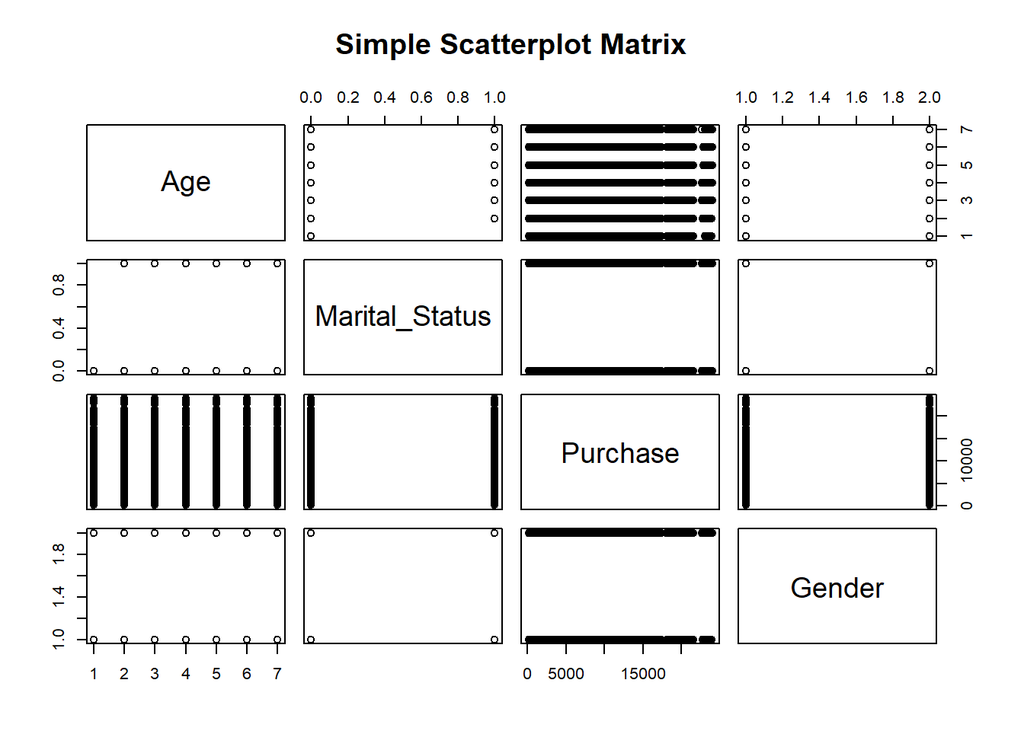

```r
# Basic Scatterplot Matrix
pairs(~Age+Marital_Status+Purchase+Gender,data=bf_data,
   main="Simple Scatterplot Matrix")
```

Interpretation: Apparently, the visualization of (Multi-) Colinearity cannot be done by a simple scatterplot matrix for categorical variables. For further investigation one should consider other alternatives.

__

Continue with Part2: 2.Modelling